# Gender voice

### Wczytanie odpowiednich bibliotek

```r
library("tuneR")
library("seewave")
library("reticulate")
use_python("C:\\Users\\01143557\\AppData\\Local\\Programs\\Python\\Python39\\python.exe", required = TRUE)
library(signal, warn.conflicts = F, quietly = T)
library(oce, warn.conflicts = F, quietly = T)
```

### Stworzenie funkcji odpowiadajcych za dalsze wykresy oraz za stworzenie finalnej ramki danych

```r
meski <- readWave("sample.wav")
zenski <- readWave("mamiko.wav")

filter <- function(wave){
  wave <- ffilter(wave, from=0, to=280)
  wave
}


duration <- function(sample){
  dur = length(sample@left)/sample@samp.rate
  dur
}

sample_rate <- function(sample){
  fs = sample@samp.rate
  fs
}


frequency_plot <- function(sample){
  plot(sample@left[30700:31500], type = "l", main = "Sample",
     xlab = "Time", ylab = "Frequency")

}


waveform <- function(sample){
  sl <- sample@left
  sl = sl - mean(sl)
  plot(sl, type = 'l', xlab = 'Samples', ylab = 'Amplitude')
}

spectogram <- function(sample){
  sl <- sample@left
  spec = specgram(x = sl,
                  n = 1024,
                  Fs = sample_rate(sample),
                  window = 256,
                  overlap = 128)

  P = abs(spec$S)
  P = P/max(P)
  P = 10*log10(P)
  t = spec$t

  imagep(x = t, y = spec$f, z = t(P), col = oce.colorsViridis,
         ylab = 'Frequency [Hz]', xlab = 'Time [s]', drawPalette = T, decimate = F)
}

to_data_frame <- function(sample){
  filtered_glos <- filter(sample)
  specprop(meanspec(filtered_glos, f= 44100), f=44100)
  minfun <- min(fund(sample, fmax=280)[,2], na.rm=TRUE)
  meanfun <- mean(fund(sample, fmax=280)[,2], na.rm=TRUE)
  df <- data.frame(specprop(meanspec(filtered_glos, f= 44100), f=44100), "meanfun" <- meanfun, "minfun" <-  minfun)
  colnames(df)[1] <- c("meanfreq")
  colnames(df)[15:16] <- c("meanfun", "minfun")
  colnames(df)[9] <- c("centroid")
  colnames(df)[13] <- c("sp.ent")
  df
}
```

### Dlugosc naszego dzwieku:

##### meski:

```r
duration(meski)
```

```
[1] 7.692222
```

##### zenski:

```r
duration(zenski)
```

```
[1] 9.080499
```

### Liczba sampli na sekunde mierzona w Hz:

##### meski

```r
sample_rate(meski)
```

```
[1] 44100
```

##### zenski

```r
sample_rate(zenski)
```

```
[1] 44100
```

### Wykres zaleznosci kolejnego sampla od amplitudy:

##### meski

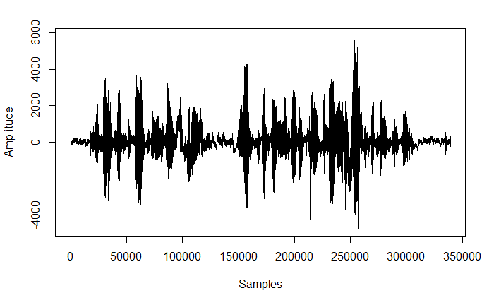

```r
waveform(meski)
```

##### zenski

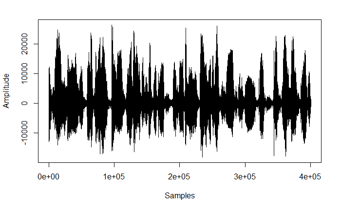

```r
waveform(zenski)
```

##### meski

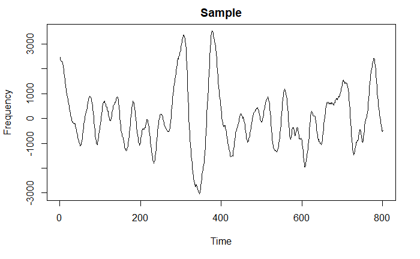

```r
frequency_plot(meski)
```

##### zenski

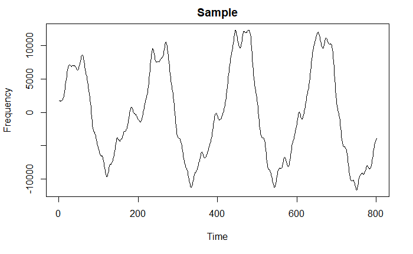

```r
frequency_plot(zenski)
```

### Spektogram naszego dzwieku, mozemy zauwazyc, w jakich czestotliwosciach wystepowaly poszczegolne sample

##### meski

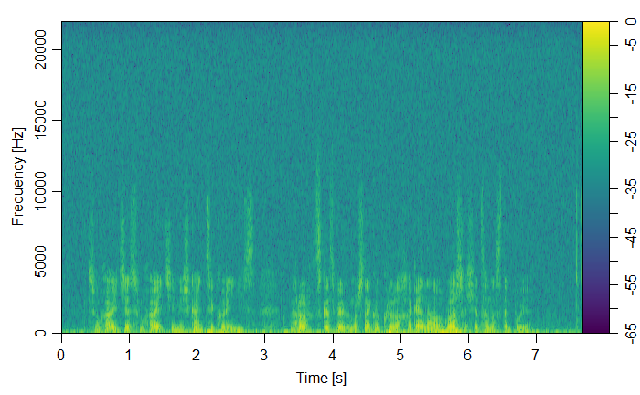

```r
spectogram(meski)
```

##### zenski

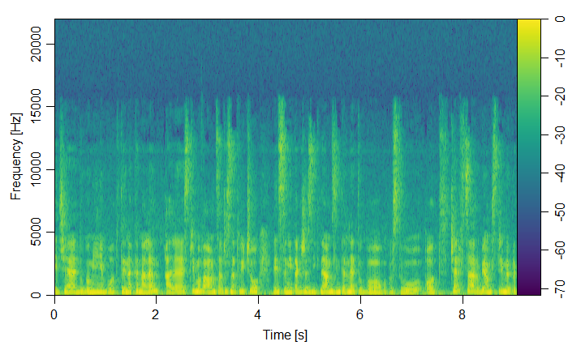

```r
spectogram(zenski)
```

### Zapisanie naszego dzwiekuw postaci takiej samej co w przypadku ramki danych ze strony [link](https://www.apispreadsheets.com/datasets/119)

##### meski

```r
meski_df
```

| meanfreq | sd | median | sem | mode | Q25 | Q75 | IQR | centroid | skewness | kurtosis | sfm | sp.ent | prec | meanfun | minfun |
| --- | --- | --- | --- | --- | --- | --- | --- | --- | --- | --- | --- | --- | --- | --- | --- |
| 104.1658 | 111.34 | 86.47059 | 6.958752 | 0 | 0 | 172.9412 | 172.9412 | 104.1658 | 8.987026 | 85.87542 | 3.224145e-05 | 0.2587176 | 86.13281 | 0.2171053 | 0.1729412 |

##### zenski

```r
zenski_df
```

| meanfreq | sd | median | sem | mode | Q25 | Q75 | IQR | centroid | skewness | kurtosis | sfm | sp.ent | prec | meanfun | minfun |
| --- | --- | --- | --- | --- | --- | --- | --- | --- | --- | --- | --- | --- | --- | --- | --- |
| 201.4888 | 107.5855 | 172.9412 | 6.724096 | 172.9412 | 172.9412 | 259.4118 | 86.47059 | 201.4888 | 10.05104 | 106.8597 | 3.552391e-05 | 0.2586705 | 86.13281 | 0.2196719 | 0.1729412 |

## Do eksploracji naszego zbioru danych użylismy Pythona.

### Importowanie niezbednych bibliotek

```python
import pandas as pd
import numpy as np
import seaborn as sns
import matplotlib.pyplot as plt
import matplotlib
import requests
```

### Wczytanie ramki danych, wywolanie head()

```
   meanfreq        sd    median       Q25  ...    maxdom   dfrange   modindx  label
0  0.059781  0.064241  0.032027  0.015071  ...  0.007812  0.000000  0.000000   male
1  0.066009  0.067310  0.040229  0.019414  ...  0.054688  0.046875  0.052632   male
2  0.077316  0.083829  0.036718  0.008701  ...  0.015625  0.007812  0.046512   male
3  0.151228  0.072111  0.158011  0.096582  ...  0.562500  0.554688  0.247119   male
4  0.135120  0.079146  0.124656  0.078720  ...  5.484375  5.476562  0.208274   male

[5 rows x 21 columns]
```

### Objasnienie danych zawartych w ramce

- meanfreq - srednia czestotliwosc (w kHz)
- sd - odchylenie standardowe
- median - mediana czestotliwosci (w kHz)
- Q25 - pierwszy kwantyl czestotliwosci (w kHz)
- Q75 - trzeci kwantyl (w kHz)
- IQR - Rozstep cwiartkowy (w kHz)
- skew - skosnosc
- kurt - kurtoza
- sp.ent - entropia spektrum - mierzy nieregularnosc sygnalu
- sfm - plaskosc spektrum - pokazuje jak bardzo sygnal jest plaski w opozycji do bycia szumem
- mode - moda czestotliwosci
- centroid - wskazuje centrum masy spektrum
- meanfun - srednia czestotliwosci tonu podstawowego - najnizszego tonu - dzwieku szeregu harmonicznego
- minfun - minimum czestotliwosci tonu podstawowego
- maxfun - maksimum czestotliwosci tonu podstawowego
- meandom - srednia czestotliwosci z najwieksza ampliduda
- mindom - minimum czestotliwosci z najwieksza ampliduda
- maxdom - maksimum czestotliwosci z najwieksza ampliduda
- dfrange - zasieg najwiekszej amplitudy tonu podstawowego
- modindx - wskaznik dewiacji czestotliwosci - iloczyn czestotliwosci sygnalu nosnego do dewiacji czestotliwosci

### Wywolanie info()

```
<class 'pandas.core.frame.DataFrame'>
RangeIndex: 3168 entries, 0 to 3167
Data columns (total 21 columns):
 #   Column    Non-Null Count  Dtype
---  ------    --------------  -----
 0   meanfreq  3168 non-null   float64
 1   sd        3168 non-null   float64
 2   median    3168 non-null   float64
 3   Q25       3168 non-null   float64
 4   Q75       3168 non-null   float64
 5   IQR       3168 non-null   float64
 6   skew      3168 non-null   float64
 7   kurt      3168 non-null   float64
 8   sp.ent    3168 non-null   float64
 9   sfm       3168 non-null   float64
 10  mode      3168 non-null   float64
 11  centroid  3168 non-null   float64
 12  meanfun   3168 non-null   float64
 13  minfun    3168 non-null   float64
 14  maxfun    3168 non-null   float64
 15  meandom   3168 non-null   float64
 16  mindom    3168 non-null   float64
 17  maxdom    3168 non-null   float64
 18  dfrange   3168 non-null   float64
 19  modindx   3168 non-null   float64
 20  label     3168 non-null   object
dtypes: float64(20), object(1)
memory usage: 519.9+ KB
```

##### Jak widac nie mamy zadnych brakujacych wartosci

### Histogramy przedstawiajace rozklad kazdej zmiennej objasniajacej

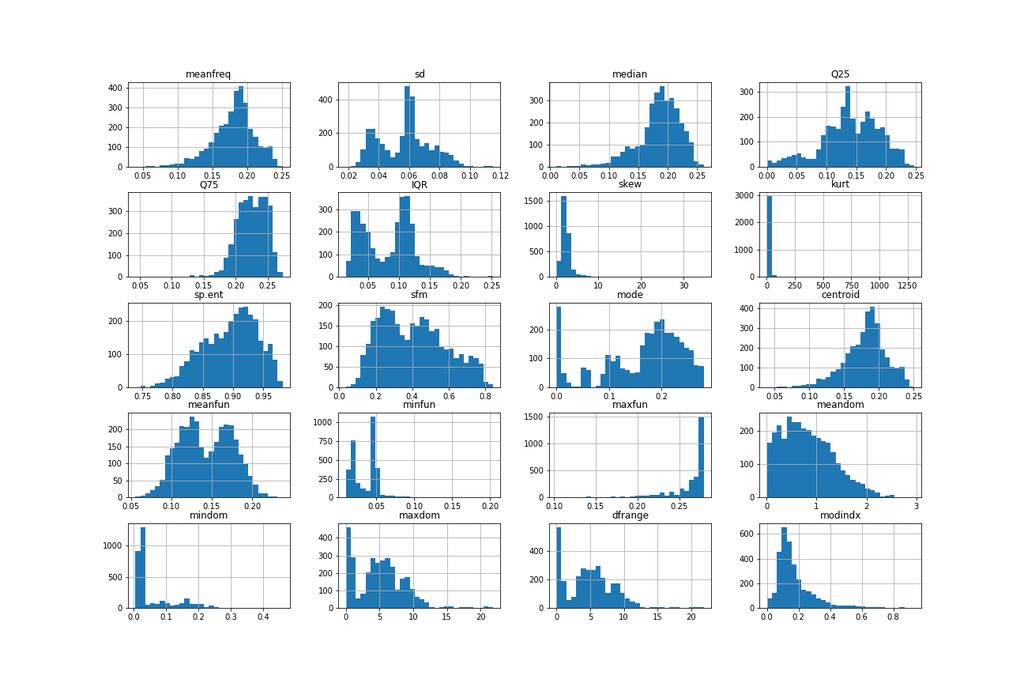

```python
voice_df.hist(figsize=(18, 12), bins=30);
plt.show()
```

### Heatmapa przedstawiajaca korelacje pomiedzy zmiennymi

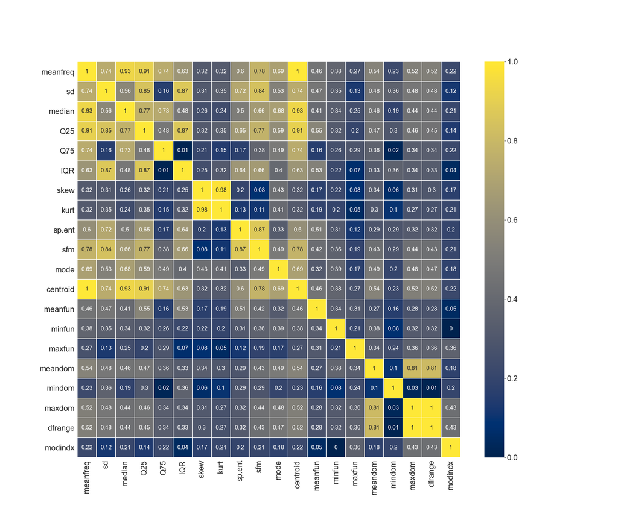

### Pairploty dla czterech najbardziej charakterystycznych zmiennych

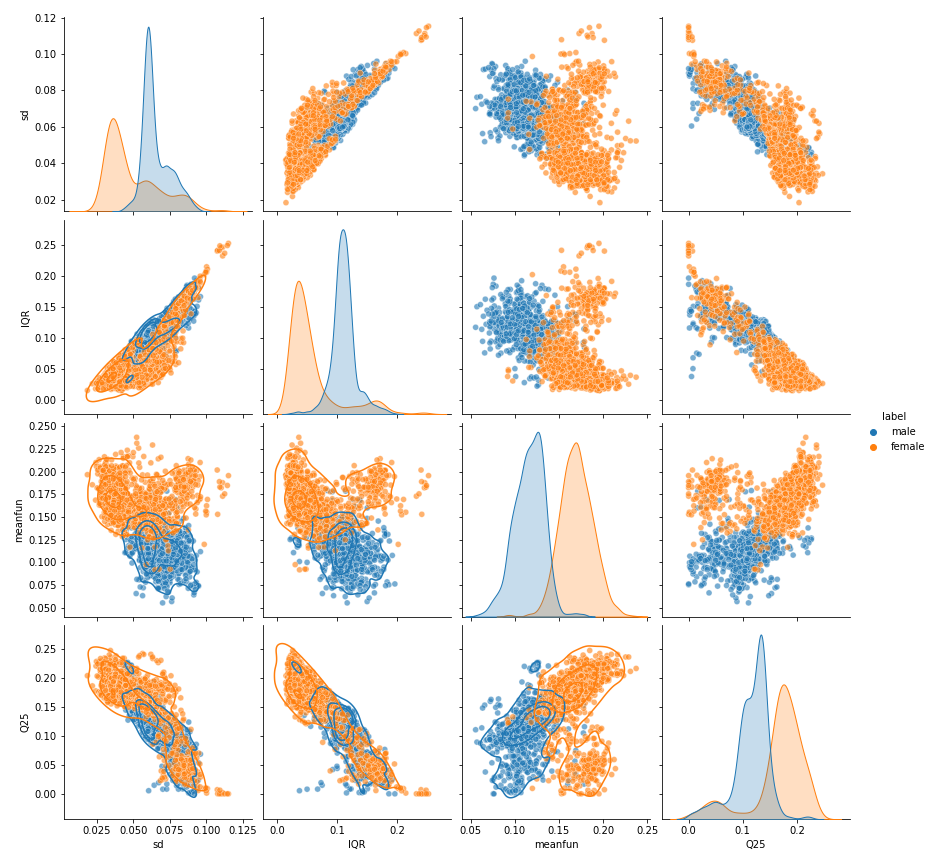

```python
g = sns.pairplot(voice_df[['sd', 'IQR', 'meanfun', 'Q25', 'label']], hue = 'label', height = 3,  plot_kws = {'alpha': 0.6})
g.map_lower(sns.kdeplot, levels=4, color=".2");
plt.show()
```

### Ridgeploty dla dwóch zmiennych, których nie udalo nam sie zreprodukowac

```python
def ridgeplot(voice_df, label1):
    rp = sns.FacetGrid(voice_df, row="label", hue="label", aspect=5, height=1.25)
    rp.map(sns.kdeplot, label1, bw_adjust=.5, clip_on=False, fill=True, alpha=1, linewidth=1.5)
    rp.map(sns.kdeplot, label1, clip_on=False, color="w", lw=2, bw_adjust=.5)
    rp.map(plt.axhline, y=0, lw=2, clip_on=False)
    def label(x, color, label):
        ax = plt.gca()
        ax.text(0, .2, label, fontweight="bold", color=color, ha="left", va="center", transform=ax.transAxes)
    rp.map(label, label1)
    rp.set_titles("")
    rp.despine(bottom=True, left=True)
    rp.fig.tight_layout()

cols = voice_df.columns.values[0:18].tolist
```

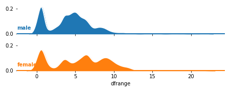

```python
ridgeplot(voice_df, "dfrange")
plt.show()
```

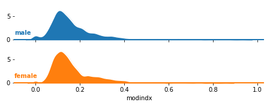

```python
ridgeplot(voice_df, "modindx")
plt.show()
```